# Exposure: maps and time trends

- Show All Code
- Hide All Code
- View Source

Deliverable 1 · Heatwaves, ozone and mortality in Santiago, 2009-2020

Author

Amaru Agüero Jiménez

Published

November 23, 2026

## 1 Scope

Distribution of the single exposures (temperature, heatwaves, ozone) and of the compound exposure (a heatwave day with high ozone) across the 33 municipalities and the warm seasons of 2009 to 2020. All figures use the days between 1 November and 31 March.

Where one definition has to be shown, the page uses the working definitions of `config/config.yml`: heatwave hw_p95_2d, ozone series o3_idw, high ozone above the 75th percentile of the municipality. They are working values, not final choices; the grid at the end of the page covers every combination.

**Code/13_exposure_merge_qc.R (builds the dataset and the frequency tables used here)**

```r
# 13_exposure_merge_qc.R
# Exposure dataset 2009-2020: temperature, heatwaves, ozone and co-pollutants
# by municipality and day, with the checks of temporal alignment.
#
# Inputs
#   Data/Derived/exposure_temperature.csv      (script 10)
#   Data/Derived/exposure_air_pollution.csv    (script 11)
#   Data/Derived/ozone_rebuilt_municipal.csv   (script 12)
#   inputs$sinca_opr                           station temperature, alignment check only
# Outputs
#   Data/Derived/exposure_2009_2020.csv            the exposure dataset
#   Output/Tables/exposure_alignment.csv           coverage of each source
#   Output/Tables/temporal_alignment_lags.csv      CR2MET against SINCA temperature
#   Output/Tables/ozone_cutoffs.csv                percentile cut-offs by municipality
#   Output/Tables/compound_frequency_by_municipality.csv
#   Output/Tables/compound_frequency_by_year.csv
#   Output/Tables/exposure_codebook.csv
#
# The dataset holds every day of the study years plus the days before the
# first one that the lagged exposures need. `in_study_period` and
# `warm_season` mark the days of analysis (1 November to 31 March).

source(here::here("Code", "00_setup.R"))
source(here::here("Code", "01_functions.R"))

municipalities <- study_municipalities()
study_years <- get_param("study", "years")
cutoffs <- unlist(get_param("air_pollution", "ozone_percentile_cutoffs"))
scope <- get_param("air_pollution", "ozone_percentile_scope")
stopifnot(scope == "municipality")
lag_buffer <- max(unlist(get_param("design", "lags_days")))
keep_dates <- study_dates(buffer_days = lag_buffer)

read_derived <- function(file) {
  dt <- fread(derived_path(file), encoding = "UTF-8")
  dt[, date := as.Date(date)]
  dt
}
temperature <- read_derived("exposure_temperature.csv")
pollution <- read_derived("exposure_air_pollution.csv")
rebuilt <- read_derived("ozone_rebuilt_municipal.csv")

# ---- 1. Alignment: every source covers the same municipality-day grid -------

grid <- CJ(com = municipalities$code, date = keep_dates)
coverage <- function(dt, source) {
  keys <- dt[, .(com, date)]
  data.table(
    source = source, rows = nrow(dt), municipalities = uniqueN(dt$com),
    first_date = min(dt$date), last_date = max(dt$date), days = uniqueN(dt$date),
    repeated_keys = sum(duplicated(keys)),
    keys_missing_from_grid = nrow(fsetdiff(grid, keys)),
    keys_outside_grid = nrow(fsetdiff(keys, grid))
  )
}
alignment <- rbind(
  coverage(temperature, "temperature (CR2MET)"),
  coverage(pollution, "air pollution (SINCA, delivered)"),
  coverage(rebuilt, "ozone rebuilt from hourly records")
)
fwrite(alignment, file.path(dir_tables, "exposure_alignment.csv"))
stopifnot(all(alignment$repeated_keys == 0), all(alignment$keys_missing_from_grid == 0),
          all(alignment$keys_outside_grid == 0))

# ---- 2. Alignment of the calendars: CR2MET against SINCA temperature --------

# Day-to-day changes of the CR2MET maximum temperature are correlated with the
# day-to-day changes of the SINCA station temperature shifted by -2 to +2
# days. Aligned calendars give the highest correlation at shift 0. Leap years
# are looked at separately after 29 February, the day absent from CR2MET.
sinca_temp <- read_sinca_interpolated(
  input_path(paste0("sinca_", get_param("air_pollution", "series_version_main"))),
  municipalities, "temp", date_from = min(keep_dates), date_to = max(keep_dates)
)
check <- merge(temperature[, .(com, date, tmax, temp_filled)],
               sinca_temp[, .(com, date, sinca_temp = temp_idw)], by = c("com", "date"))
setorder(check, com, date)
check[, d_tmax := tmax - shift(tmax), by = com]
# Changes that involve a filled 29 February are left out
check[, original_pair := !temp_filled & !shift(temp_filled), by = com]
check[, leap_year_after_feb := (year(date) %% 4 == 0) & month(date) >= 3]
lag_table <- rbindlist(lapply(-2:2, function(k) {
  check[, d_sinca := shift(sinca_temp, n = -k) - shift(sinca_temp, n = -k + 1), by = com]
  check[original_pair == TRUE & !is.na(d_sinca),
        .(shift_days = k, n = .N, correlation = cor(d_tmax, d_sinca)),
        by = .(period = fifelse(leap_year_after_feb, "leap years, March to December",
                                "all other days"))]
}))
setorder(lag_table, period, shift_days)
fwrite(lag_table, file.path(dir_tables, "temporal_alignment_lags.csv"))
best <- lag_table[, .SD[which.max(correlation)], by = period]
if (!all(best$shift_days == 0)) {
  stop("CR2MET and SINCA calendars are not aligned: see temporal_alignment_lags.csv",
       call. = FALSE)
}

# ---- 3. Merge ---------------------------------------------------------------

exposure <- merge(temperature, pollution[, !"municipality"], by = c("com", "date"))
exposure <- merge(exposure, rebuilt[, !"municipality"], by = c("com", "date"))
stopifnot(nrow(exposure) == nrow(grid))
exposure[, in_study_period := year >= study_years[1] & year <= study_years[2]]

# ---- 4. Ozone categories by municipality-specific percentiles ---------------

# Six ozone series: delivered (o3), rebuilt 24-hour mean (o3obs) and rebuilt
# MDA8 (o3mda8), each by IDW and by ordinary kriging. Cut-offs are the
# percentiles of the warm-season days of the study years in each municipality.
ozone_series <- as.vector(outer(c("o3", "o3obs", "o3mda8"), c("idw", "ok"), paste, sep = "_"))
cutoff_tables <- list()
for (series in ozone_series) {
  cut <- exposure[in_study_period & warm_season & !is.na(get(series)),
                  as.list(stats::quantile(get(series), cutoffs / 100, type = 7, names = FALSE)),
                  by = com]
  setnames(cut, c("com", paste0("p", cutoffs)))
  cutoff_tables[[series]] <- cbind(series = series, cut)
  exposure <- merge(exposure, cut, by = "com")
  for (p in cutoffs) {
    exposure[, (paste0(series, "_gt_p", p)) := as.integer(get(series) > get(paste0("p", p)))]
  }
  exposure[, (paste0("p", cutoffs)) := NULL]
}
ozone_cutoffs <- merge(municipalities, rbindlist(cutoff_tables), by.x = "code", by.y = "com")
setnames(ozone_cutoffs, c("code", "name"), c("com", "municipality"))
setorder(ozone_cutoffs, series, com)
fwrite(ozone_cutoffs, file.path(dir_tables, "ozone_cutoffs.csv"))

# ---- 5. Frequency of compound exposure over the definition grid -------------

heatwaves <- grep("^hw_", names(exposure), value = TRUE)
ozone_flags <- grep("_gt_p[0-9]+$", names(exposure), value = TRUE)
days <- exposure[in_study_period & warm_season]
compound_counts <- function(by_column) {
  rbindlist(lapply(heatwaves, function(hw) rbindlist(lapply(ozone_flags, function(oz) {
    days[, category := compound_category(get(hw), get(oz))]
    out <- days[, .(
      days = .N, e00 = sum(category == "E00", na.rm = TRUE),
      e10 = sum(category == "E10", na.rm = TRUE), e01 = sum(category == "E01", na.rm = TRUE),
      e11 = sum(category == "E11", na.rm = TRUE), not_classified = sum(is.na(category))
    ), by = by_column]
    cbind(heatwave = hw, ozone = oz, out)
  }))))
}
by_municipality <- merge(municipalities, compound_counts("com"), by.x = "code", by.y = "com")
setnames(by_municipality, c("code", "name"), c("com", "municipality"))
fwrite(by_municipality, file.path(dir_tables, "compound_frequency_by_municipality.csv"))
fwrite(compound_counts("year"), file.path(dir_tables, "compound_frequency_by_year.csv"))

# ---- 6. Save the dataset and its codebook -----------------------------------

setcolorder(exposure, c("com", "municipality", "date", "year", "in_study_period", "warm_season"))
setorder(exposure, com, date)
fwrite(exposure, file.path(dir_derived, "exposure_2009_2020.csv"))

describe <- function(name) {
  rules <- list(
    "^com$" = "Municipality code (INE)",
    "^municipality$" = "Municipality name",
    "^date$" = "Calendar day",
    "^year$" = "Calendar year",
    "^in_study_period$" = "Day inside the study years (FALSE for the lag buffer days)",
    "^warm_season$" = "Day between 1 November and 31 March",
    "^tmax$" = "Daily maximum temperature, CR2MET v2.5 (degrees C)",
    "^tmin$" = "Daily minimum temperature, CR2MET v2.5 (degrees C)",
    "^temp_filled$" = "Temperature absent from CR2MET (29 February), filled as configured",
    "^tad$" = "Daily mean temperature: (tmax + next-day tmin) / 2 (degrees C)",
    "^hot_" = "Maximum temperature above the threshold in the name (1/0)",
    "^hw_ehf_" = "Heatwave day: excess heat factor above zero, window in the name (1/0)",
    "^hw_" = "Heatwave day: at least the n-th consecutive day above the threshold (1/0)",
    "^ehf_" = "Excess heat factor, window in the name (degrees C squared)",
    "_gt_p[0-9]+$" = "Ozone above the municipality percentile in the name, warm-season days of the study years (1/0)",
    "_ok_warning$" = "Variogram fit raised a warning that day",
    "_ok_failed$" = "Variogram could not be fitted that day (too few stations); kriging value missing",
    "_n_stations$" = "Stations with a value that day",
    "_ok_var$" = "Ordinary kriging variance",
    "^o3obs_" = "Ozone, 24-hour mean rebuilt from hourly records without trimming or imputation (ppb)",
    "^o3mda8_" = "Ozone, daily maximum 8-hour mean rebuilt from hourly records (ppb)",
    "^o3_" = "Ozone, 24-hour mean, delivered interpolated series (ppb)",
    "^pm25_" = "PM2.5, delivered interpolated series (ug/m3)",
    "^no2_" = "Nitrogen dioxide, delivered interpolated series (ppb)",
    "^hum_" = "Relative humidity, delivered interpolated series (percent)"
  )
  for (pattern in names(rules)) if (grepl(pattern, name)) return(rules[[pattern]])
  stop("No codebook entry for column: ", name, call. = FALSE)
}
codebook <- data.table(
  variable = names(exposure),
  description = vapply(names(exposure), describe, character(1)),
  missing = vapply(exposure, function(x) sum(is.na(x)), integer(1))
)
fwrite(codebook, file.path(dir_tables, "exposure_codebook.csv"))

message("exposure_2009_2020.csv: ", nrow(exposure), " rows, ", ncol(exposure), " columns; ",
        exposure[in_study_period & warm_season, .N],
        " municipality-days in the warm seasons of the study years")
```

## 2 Single exposures

```r
variables <- c(tmax = "Maximum temperature (°C)", tmin = "Minimum temperature (°C)",
               o3_idw = "Ozone, delivered 24-hour mean, IDW (ppb)",
               o3_ok = "Ozone, delivered 24-hour mean, kriging (ppb)",
               o3obs_idw = "Ozone, rebuilt 24-hour mean, IDW (ppb)",
               o3mda8_idw = "Ozone, rebuilt MDA8, IDW (ppb)",
               o3mda8_ok = "Ozone, rebuilt MDA8, kriging (ppb)",
               pm25_idw = "PM2.5, IDW (µg/m³)", no2_idw = "Nitrogen dioxide, IDW (ppb)",
               hum_idw = "Relative humidity, IDW (%)")
descriptive <- rbindlist(lapply(names(variables), function(v) {
  x <- analysis[[v]]
  q <- quantile(x, c(0.05, 0.25, 0.5, 0.75, 0.95), na.rm = TRUE)
  data.table(variable = variables[[v]], n = sum(!is.na(x)), missing = sum(is.na(x)),
             mean = mean(x, na.rm = TRUE), sd = sd(x, na.rm = TRUE),
             p5 = q[1], p25 = q[2], median = q[3], p75 = q[4], p95 = q[5])
}))
kable(descriptive, digits = 1, format.args = list(big.mark = ","),
      col.names = c("Variable", "N", "Missing", "Mean", "SD", "P5", "P25", "Median", "P75", "P95"))
```

Table 1: Exposure variables over the municipality-days of the warm seasons 2009-2020.

| Variable | N | Missing | Mean | SD | P5 | P25 | Median | P75 | P95 |
| --- | --- | --- | --- | --- | --- | --- | --- | --- | --- |
| Maximum temperature (°C) | 59,895 | 0 | 28.7 | 3.9 | 20.8 | 27.0 | 29.4 | 31.4 | 33.8 |
| Minimum temperature (°C) | 59,895 | 0 | 11.4 | 2.1 | 7.7 | 10.1 | 11.5 | 12.8 | 14.5 |
| Ozone, delivered 24-hour mean, IDW (ppb) | 59,895 | 0 | 19.9 | 4.3 | 12.8 | 17.2 | 20.0 | 22.7 | 26.6 |
| Ozone, delivered 24-hour mean, kriging (ppb) | 59,885 | 10 | 20.1 | 4.3 | 12.9 | 17.5 | 20.2 | 22.9 | 26.4 |
| Ozone, rebuilt 24-hour mean, IDW (ppb) | 59,823 | 72 | 20.5 | 5.1 | 12.7 | 17.2 | 20.3 | 23.5 | 28.6 |
| Ozone, rebuilt MDA8, IDW (ppb) | 59,815 | 80 | 41.4 | 10.5 | 24.9 | 34.5 | 41.3 | 48.1 | 58.2 |
| Ozone, rebuilt MDA8, kriging (ppb) | 59,795 | 100 | 41.6 | 10.1 | 25.5 | 34.9 | 41.6 | 48.1 | 57.6 |
| PM2.5, IDW (µg/m³) | 59,895 | 0 | 18.7 | 7.1 | 9.9 | 14.1 | 17.6 | 21.8 | 31.3 |
| Nitrogen dioxide, IDW (ppb) | 59,872 | 23 | 16.1 | 5.8 | 8.3 | 12.0 | 15.2 | 19.2 | 26.6 |
| Relative humidity, IDW (%) | 59,895 | 0 | 50.5 | 10.5 | 35.1 | 42.5 | 49.5 | 57.6 | 69.3 |

### 2.1 Maps

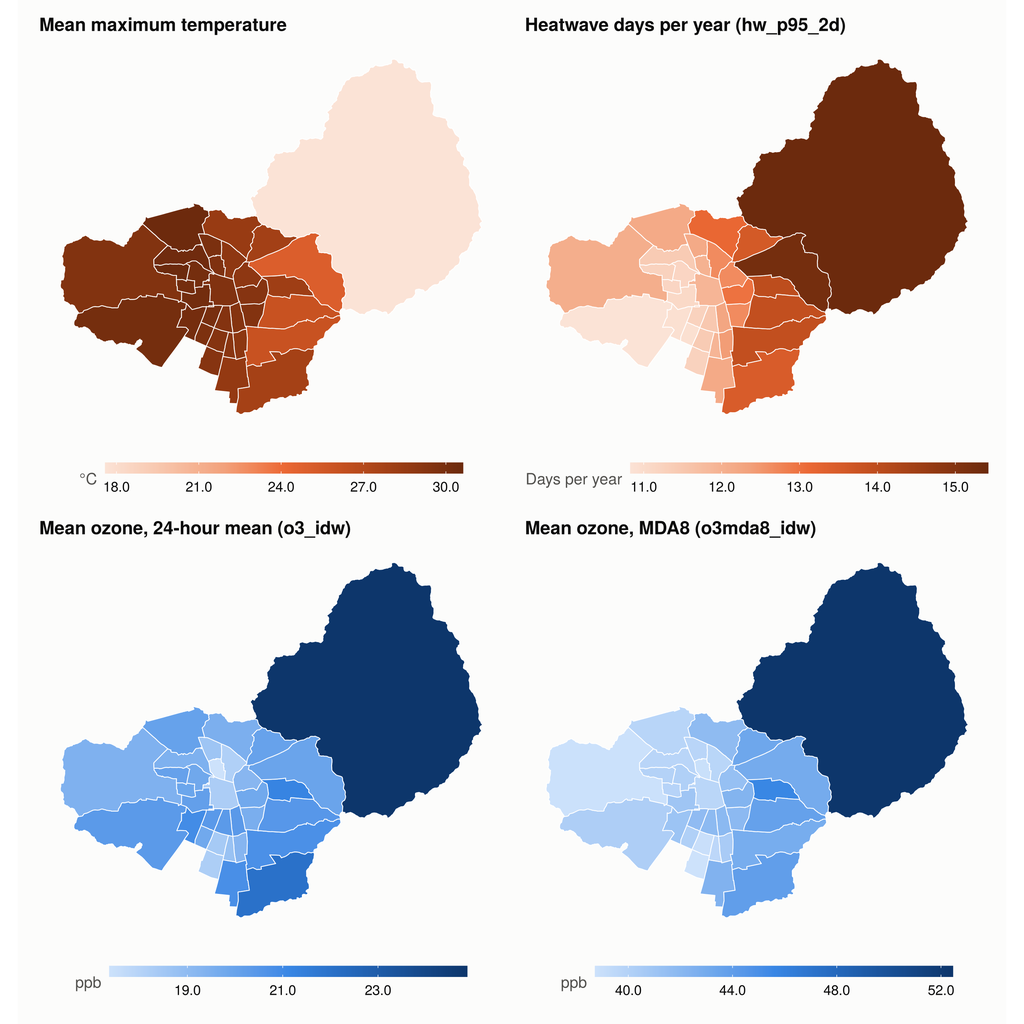

Figure 1: Mean maximum temperature, heatwave days per year and mean ozone by municipality, warm seasons 2009-2020.

```r
by_mun <- analysis[, .(
  tmax = mean(tmax), hw_days = sum(get(heatwave_main)) / 12,
  hot30 = sum(hot_30c) / 12,
  o3 = mean(get(ozone_main), na.rm = TRUE), mda8 = mean(o3mda8_idw, na.rm = TRUE)
), by = com]
patchwork::wrap_plots(
  map_values(by_mun, "tmax", "Mean maximum temperature", "°C", hue = "orange"),
  map_values(by_mun, "hw_days", paste0("Heatwave days per year (", heatwave_main, ")"),
             "Days per year", hue = "orange"),
  map_values(by_mun, "o3", paste0("Mean ozone, 24-hour mean (", ozone_main, ")"), "ppb"),
  map_values(by_mun, "mda8", "Mean ozone, MDA8 (o3mda8_idw)", "ppb"),
  ncol = 2
)
```

```r
table_mun <- merge(study_municipalities(), by_mun, by.x = "code", by.y = "com")
kableExtra::scroll_box(
  kableExtra::kable_styling(
    kable(table_mun, format = "html", digits = 1,
          col.names = c("Code", "Municipality", "Mean maximum temperature (°C)",
                        "Heatwave days per year", "Days above 30 °C per year",
                        "Ozone, 24-hour mean (ppb)", "Ozone, MDA8 (ppb)")),
    bootstrap_options = c("striped", "condensed"), font_size = 12),
  height = "380px"
)
```

Table 2: Values of the maps, with the number of days above 30 °C per year.

| Code | Municipality | Mean maximum temperature (°C) | Heatwave days per year | Days above 30 °C per year | Ozone, 24-hour mean (ppb) | Ozone, MDA8 (ppb) |
| --- | --- | --- | --- | --- | --- | --- |
| 13101 | Santiago | 29.5 | 11.9 | 75.5 | 18.3 | 39.7 |
| 13102 | Cerrillos | 30.2 | 10.9 | 88.9 | 20.9 | 41.1 |
| 13103 | Cerro Navia | 30.6 | 11.2 | 97.7 | 20.1 | 40.0 |
| 13104 | Conchalí | 29.9 | 12.2 | 83.7 | 18.6 | 39.7 |
| 13105 | El Bosque | 29.3 | 11.2 | 70.8 | 18.2 | 38.7 |
| 13106 | Estación Central | 30.3 | 11.1 | 90.8 | 20.2 | 41.0 |
| 13107 | Huechuraba | 28.4 | 13.2 | 48.7 | 19.5 | 41.8 |
| 13108 | Independencia | 29.6 | 12.0 | 77.9 | 17.4 | 38.9 |
| 13109 | La Cisterna | 29.4 | 11.4 | 71.2 | 18.4 | 38.9 |
| 13110 | La Florida | 26.1 | 13.9 | 11.2 | 20.8 | 42.9 |
| 13111 | La Granja | 29.0 | 12.4 | 62.4 | 19.3 | 40.5 |
| 13112 | La Pintana | 28.7 | 12.2 | 54.8 | 20.8 | 42.4 |
| 13113 | La Reina | 28.1 | 14.0 | 41.9 | 21.2 | 45.6 |
| 13114 | Las Condes | 25.0 | 15.2 | 3.1 | 20.0 | 43.0 |
| 13115 | Lo Barnechea | 17.6 | 15.4 | 0.0 | 24.9 | 52.4 |
| 13116 | Lo Espejo | 29.8 | 10.9 | 80.6 | 19.8 | 40.2 |
| 13117 | Lo Prado | 30.2 | 11.2 | 89.2 | 19.9 | 39.9 |
| 13118 | Macul | 29.5 | 12.7 | 73.3 | 19.6 | 41.9 |
| 13119 | Maipú | 30.1 | 10.8 | 88.1 | 20.4 | 40.3 |
| 13120 | Ñuñoa | 29.3 | 13.0 | 70.2 | 19.8 | 42.3 |
| 13121 | Pedro Aguirre Cerda | 30.0 | 11.2 | 86.2 | 20.4 | 41.7 |
| 13122 | Peñalolén | 26.1 | 13.9 | 11.2 | 20.5 | 43.7 |
| 13123 | Providencia | 28.9 | 12.7 | 59.6 | 19.2 | 41.4 |
| 13124 | Pudahuel | 29.5 | 12.1 | 74.5 | 19.4 | 38.9 |
| 13125 | Quilicura | 30.6 | 12.2 | 97.8 | 20.1 | 39.8 |
| 13126 | Quinta Normal | 30.2 | 11.2 | 89.0 | 19.8 | 40.2 |
| 13127 | Recoleta | 28.9 | 12.7 | 59.7 | 18.1 | 39.7 |
| 13128 | Renca | 30.4 | 11.4 | 94.7 | 19.5 | 39.7 |
| 13129 | San Joaquín | 29.3 | 12.2 | 71.2 | 20.4 | 42.0 |
| 13130 | San Miguel | 29.4 | 11.5 | 73.1 | 20.4 | 41.9 |
| 13131 | San Ramón | 29.1 | 11.9 | 65.7 | 18.7 | 39.6 |
| 13132 | Vitacura | 27.9 | 13.6 | 37.2 | 20.1 | 43.3 |
| 13201 | Puente Alto | 27.8 | 13.5 | 36.7 | 22.0 | 43.9 |

### 2.2 Time series

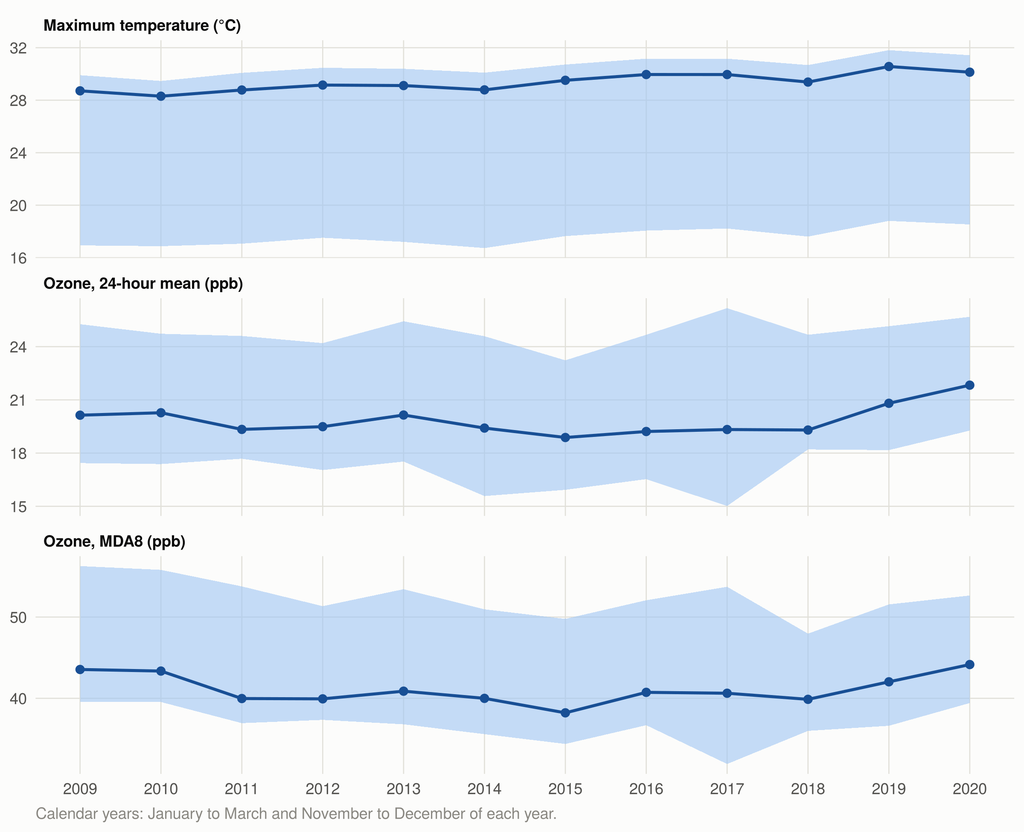

Figure 2: Warm-season means by calendar year. Line: median of the 33 municipalities; band: range between municipalities.

```r
annual <- analysis[, .(tmax = mean(tmax), o3 = mean(get(ozone_main), na.rm = TRUE),
                       mda8 = mean(o3mda8_idw, na.rm = TRUE)), by = .(com, year)]
annual_long <- melt(annual, id.vars = c("com", "year"))
annual_long[, variable := factor(variable, levels = c("tmax", "o3", "mda8"),
  labels = c("Maximum temperature (°C)", "Ozone, 24-hour mean (ppb)", "Ozone, MDA8 (ppb)"))]
bands <- annual_long[, .(median = median(value), low = min(value), high = max(value)),
                     by = .(variable, year)]
ggplot(bands, aes(year)) +
  geom_ribbon(aes(ymin = low, ymax = high), fill = ramp_blue[2], alpha = 0.6) +
  geom_line(aes(y = median), colour = ramp_blue[6], linewidth = 0.8) +
  geom_point(aes(y = median), colour = ramp_blue[6], size = 1.8) +
  facet_wrap(~variable, ncol = 1, scales = "free_y") +
  scale_x_continuous(breaks = 2009:2020) +
  labs(x = NULL, y = NULL,
       caption = "Calendar years: January to March and November to December of each year.")
```

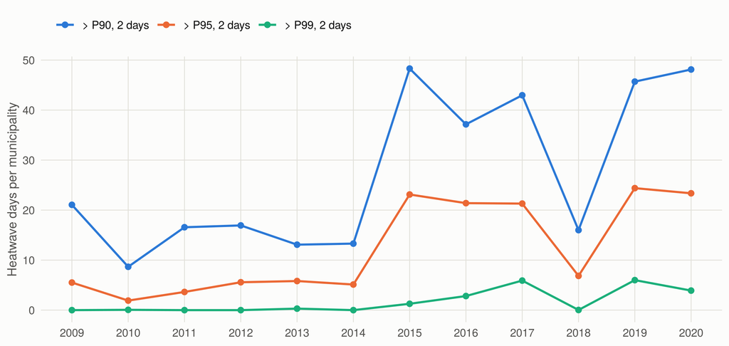

Figure 3: Heatwave days per municipality by calendar year, percentile definitions with two or more consecutive days.

```r
hw_years <- melt(analysis[, lapply(.SD, function(x) sum(x) / uniqueN(com)), by = year,
                          .SDcols = c("hw_p90_2d", "hw_p95_2d", "hw_p99_2d")],
                 id.vars = "year", variable.name = "indicator", value.name = "days")
hw_years[, indicator := factor(indicator, levels = c("hw_p90_2d", "hw_p95_2d", "hw_p99_2d"),
                               labels = c("> P90, 2 days", "> P95, 2 days", "> P99, 2 days"))]
ggplot(hw_years, aes(year, days, colour = indicator)) +
  geom_line(linewidth = 0.8) +
  geom_point(size = 1.8) +
  scale_colour_manual(values = c("> P90, 2 days" = "#2a78d6", "> P95, 2 days" = "#eb6834",
                                 "> P99, 2 days" = "#1baf7a")) +
  scale_x_continuous(breaks = 2009:2020) +
  labs(x = NULL, y = "Heatwave days per municipality", colour = NULL)
```

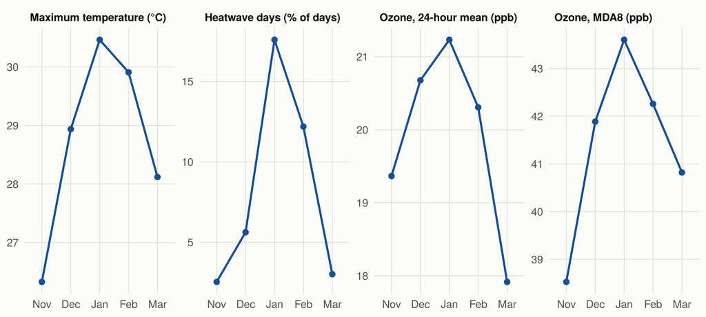

Figure 4: Seasonal profile: mean of the 33 municipalities by month of the warm season, 2009-2020.

```r
monthly <- analysis[, .(tmax = mean(tmax), o3 = mean(get(ozone_main), na.rm = TRUE),
                        mda8 = mean(o3mda8_idw, na.rm = TRUE),
                        hw = 100 * mean(get(heatwave_main))), by = .(month = month(date))]
monthly_long <- melt(monthly, id.vars = "month")
monthly_long[, month := factor(month, levels = c(11, 12, 1, 2, 3),
                               labels = c("Nov", "Dec", "Jan", "Feb", "Mar"))]
monthly_long[, variable := factor(variable, levels = c("tmax", "hw", "o3", "mda8"),
  labels = c("Maximum temperature (°C)", "Heatwave days (% of days)",
             "Ozone, 24-hour mean (ppb)", "Ozone, MDA8 (ppb)"))]
ggplot(monthly_long, aes(month, value, group = 1)) +
  geom_line(colour = ramp_blue[6], linewidth = 0.8) +
  geom_point(colour = ramp_blue[6], size = 1.8) +
  facet_wrap(~variable, nrow = 1, scales = "free_y") +
  labs(x = NULL, y = NULL)
```

## 3 Compound exposure

A municipality-day belongs to one of four categories: neither exposure (E00), heatwave only (E10), high ozone only (E01), or both (E11).

```r
analysis[, category := compound_category(get(heatwave_main), get(ozone_flag_main))]
labels <- c(E00 = "Neither", E01 = "High ozone only", E10 = "Heatwave only",
            E11 = "Heatwave and high ozone")
analysis[, category_label := factor(labels[as.character(category)], levels = labels)]
overall <- analysis[!is.na(category), .(days = .N), keyby = category_label]
overall[, share := 100 * days / sum(days)]
p_hw <- analysis[!is.na(category), mean(get(heatwave_main))]
p_oz <- analysis[!is.na(category), mean(get(ozone_flag_main))]
p_both <- analysis[!is.na(category), mean(category == "E11")]
```

```r
kable(overall, digits = 1, format.args = list(big.mark = ","),
      col.names = c("Category", "Municipality-days", "%"))
```

Table 3: Municipality-days by compound exposure category, working definitions, warm seasons 2009-2020.

| Category | Municipality-days | % |
| --- | --- | --- |
| Neither | 42,886 | 71.6 |
| High ozone only | 12,125 | 20.2 |
| Heatwave only | 2,027 | 3.4 |
| Heatwave and high ozone | 2,857 | 4.8 |

Heatwave days are 8.2% of the municipality-days and high-ozone days 25.0%. If the two were independent, 2.0% of the days would have both; the observed share is 4.8%, 2.3 times the expected one. 58% of the heatwave days are also high-ozone days.

### 3.1 Maps

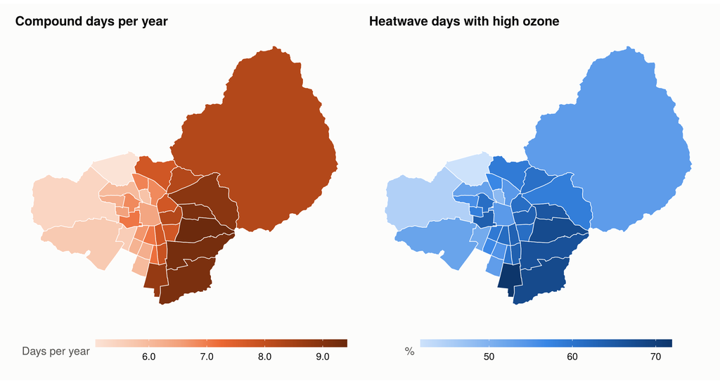

Figure 5: Compound exposure by municipality, working definitions, warm seasons 2009-2020. Left: days per year with a heatwave and high ozone. Right: share of heatwave days that are also high-ozone days.

```r
compound_mun <- analysis[!is.na(category), .(
  compound_days = sum(category == "E11") / 12,
  share_of_heatwave = 100 * sum(category == "E11") / sum(get(heatwave_main))
), by = com]
patchwork::wrap_plots(
  map_values(compound_mun, "compound_days", "Compound days per year", "Days per year",
             hue = "orange"),
  map_values(compound_mun, "share_of_heatwave", "Heatwave days with high ozone", "%",
             digits = 0),
  ncol = 2
)
```

### 3.2 By year

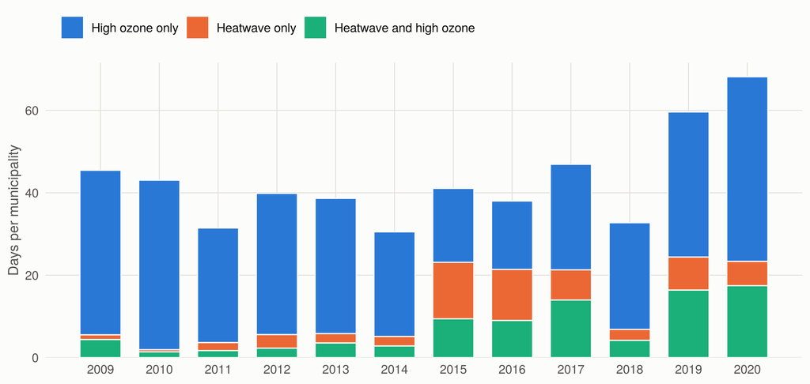

Figure 6: Exposed municipality-days by calendar year and category, working definitions, as days per municipality.

```r
by_year <- analysis[!is.na(category) & category != "E00",
                    .(days = .N / uniqueN(analysis$com)), by = .(year, category_label)]
ggplot(by_year, aes(year, days, fill = category_label)) +
  geom_col(width = 0.7, colour = ink$surface, linewidth = 0.4) +
  scale_fill_manual(values = colour_compound, drop = TRUE) +
  scale_x_continuous(breaks = 2009:2020) +
  scale_y_continuous(expand = expansion(mult = c(0, 0.05))) +
  labs(x = NULL, y = "Days per municipality", fill = NULL)
```

```r
kable(dcast(by_year, year ~ category_label, value.var = "days", fill = 0), digits = 1)
```

Table 4: Days per municipality by calendar year and category.

| year | High ozone only | Heatwave only | Heatwave and high ozone |
| --- | --- | --- | --- |
| 2009 | 39.9 | 1.1 | 4.4 |
| 2010 | 41.2 | 0.5 | 1.4 |
| 2011 | 27.8 | 1.9 | 1.7 |
| 2012 | 34.3 | 3.3 | 2.3 |
| 2013 | 32.8 | 2.3 | 3.5 |
| 2014 | 25.4 | 2.3 | 2.8 |
| 2015 | 17.9 | 13.7 | 9.4 |
| 2016 | 16.6 | 12.4 | 9.0 |
| 2017 | 25.6 | 7.3 | 14.0 |
| 2018 | 25.9 | 2.7 | 4.2 |
| 2019 | 35.2 | 8.0 | 16.4 |
| 2020 | 44.8 | 5.9 | 17.5 |

### 3.3 Across the grid of definitions

Share of municipality-days with both exposures, for the 15 heatwave definitions and the three ozone cut-offs, with the ozone series in use (o3_idw).

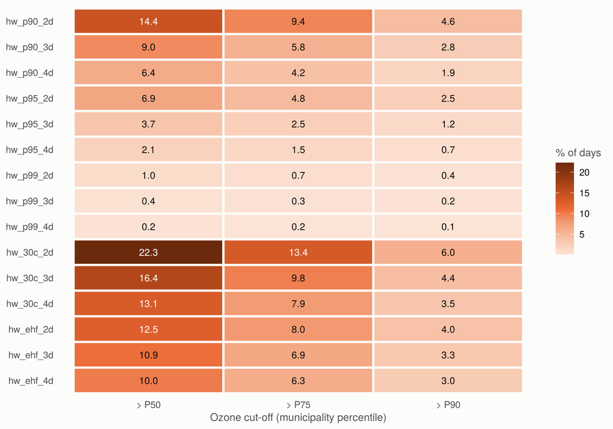

Figure 7: Compound days (% of municipality-days) by heatwave definition and ozone cut-off.

```r
grid <- read_table("compound_frequency_by_municipality.csv")
grid <- grid[grepl(paste0("^", ozone_main, "_gt_p"), ozone),
             .(e11 = sum(e11), e10 = sum(e10), e01 = sum(e01), classified = sum(days - not_classified)),
             by = .(heatwave, ozone)]
grid[, `:=`(share = 100 * e11 / classified,
            ratio = (e11 / classified) / (((e11 + e10) / classified) * ((e11 + e01) / classified)),
            cutoff = paste0("> P", sub(".*_gt_p", "", ozone)))]
grid[, heatwave := factor(heatwave, levels = rev(unique(heatwave)))]
ggplot(grid, aes(cutoff, heatwave, fill = share)) +
  geom_tile(colour = ink$surface, linewidth = 1) +
  geom_text(aes(label = sprintf("%.1f", share),
                colour = share > max(share) * 0.55), size = 3.2, show.legend = FALSE) +
  scale_colour_manual(values = c(`TRUE` = "#ffffff", `FALSE` = ink$primary)) +
  scale_fill_magnitude(name = "% of days", hue = "orange") +
  labs(x = "Ozone cut-off (municipality percentile)", y = NULL) +
  theme(panel.grid.major = element_blank(), legend.position = "right",
        legend.justification = "center")
```

```r
kableExtra::scroll_box(
  kableExtra::kable_styling(
    kable(grid[order(-as.integer(heatwave), cutoff),
               .(heatwave, cutoff, e11, share, e10, e01, ratio)],
          format = "html", digits = c(0, 0, 0, 2, 0, 0, 2), format.args = list(big.mark = ","),
          col.names = c("Heatwave", "Ozone cut-off", "Compound days (E11)", "% of days",
                        "Heatwave only (E10)", "High ozone only (E01)",
                        "Observed / expected")),
    bootstrap_options = c("striped", "condensed"), font_size = 12),
  height = "420px"
)
```

Table 5: Compound exposure across the grid: days with both exposures, and the ratio of the observed share to the share expected if heatwaves and high ozone were independent.

| Heatwave | Ozone cut-off | Compound days (E11) | % of days | Heatwave only (E10) | High ozone only (E01) | Observed / expected |
| --- | --- | --- | --- | --- | --- | --- |
| hw_p90_2d | > P50 | 8,652 | 14.45 | 2,168 | 21,279 | 1.60 |
| hw_p90_2d | > P75 | 5,614 | 9.37 | 5,206 | 9,368 | 2.07 |
| hw_p90_2d | > P90 | 2,743 | 4.58 | 8,077 | 3,263 | 2.53 |
| hw_p90_3d | > P50 | 5,367 | 8.96 | 1,483 | 24,564 | 1.57 |
| hw_p90_3d | > P75 | 3,461 | 5.78 | 3,389 | 11,521 | 2.02 |
| hw_p90_3d | > P90 | 1,687 | 2.82 | 5,163 | 4,319 | 2.46 |
| hw_p90_4d | > P50 | 3,850 | 6.43 | 1,079 | 26,081 | 1.56 |
| hw_p90_4d | > P75 | 2,489 | 4.16 | 2,440 | 12,493 | 2.02 |
| hw_p90_4d | > P90 | 1,167 | 1.95 | 3,762 | 4,839 | 2.36 |
| hw_p95_2d | > P50 | 4,157 | 6.94 | 727 | 25,774 | 1.70 |
| hw_p95_2d | > P75 | 2,857 | 4.77 | 2,027 | 12,125 | 2.34 |
| hw_p95_2d | > P90 | 1,514 | 2.53 | 3,370 | 4,492 | 3.09 |
| hw_p95_3d | > P50 | 2,227 | 3.72 | 408 | 27,704 | 1.69 |
| hw_p95_3d | > P75 | 1,498 | 2.50 | 1,137 | 13,484 | 2.27 |
| hw_p95_3d | > P90 | 746 | 1.25 | 1,889 | 5,260 | 2.82 |
| hw_p95_4d | > P50 | 1,284 | 2.14 | 236 | 28,647 | 1.69 |
| hw_p95_4d | > P75 | 893 | 1.49 | 627 | 14,089 | 2.35 |
| hw_p95_4d | > P90 | 444 | 0.74 | 1,076 | 5,562 | 2.91 |
| hw_p99_2d | > P50 | 597 | 1.00 | 73 | 29,334 | 1.78 |
| hw_p99_2d | > P75 | 414 | 0.69 | 256 | 14,568 | 2.47 |
| hw_p99_2d | > P90 | 211 | 0.35 | 459 | 5,795 | 3.14 |
| hw_p99_3d | > P50 | 240 | 0.40 | 33 | 29,691 | 1.76 |
| hw_p99_3d | > P75 | 182 | 0.30 | 91 | 14,800 | 2.67 |
| hw_p99_3d | > P90 | 108 | 0.18 | 165 | 5,898 | 3.95 |
| hw_p99_4d | > P50 | 104 | 0.17 | 5 | 29,827 | 1.91 |
| hw_p99_4d | > P75 | 94 | 0.16 | 15 | 14,888 | 3.45 |
| hw_p99_4d | > P90 | 65 | 0.11 | 44 | 5,941 | 5.95 |
| hw_30c_2d | > P50 | 13,342 | 22.28 | 5,399 | 16,589 | 1.42 |
| hw_30c_2d | > P75 | 7,999 | 13.36 | 10,742 | 6,983 | 1.71 |
| hw_30c_2d | > P90 | 3,577 | 5.97 | 15,164 | 2,429 | 1.90 |
| hw_30c_3d | > P50 | 9,805 | 16.37 | 4,293 | 20,126 | 1.39 |
| hw_30c_3d | > P75 | 5,840 | 9.75 | 8,258 | 9,142 | 1.66 |
| hw_30c_3d | > P90 | 2,646 | 4.42 | 11,452 | 3,360 | 1.87 |
| hw_30c_4d | > P50 | 7,846 | 13.10 | 3,409 | 22,085 | 1.39 |
| hw_30c_4d | > P75 | 4,710 | 7.86 | 6,545 | 10,272 | 1.67 |
| hw_30c_4d | > P90 | 2,100 | 3.51 | 9,155 | 3,906 | 1.86 |
| hw_ehf_2d | > P50 | 7,489 | 12.50 | 2,192 | 22,442 | 1.55 |
| hw_ehf_2d | > P75 | 4,799 | 8.01 | 4,882 | 10,183 | 1.98 |
| hw_ehf_2d | > P90 | 2,407 | 4.02 | 7,274 | 3,599 | 2.48 |
| hw_ehf_3d | > P50 | 6,502 | 10.86 | 2,487 | 23,429 | 1.45 |
| hw_ehf_3d | > P75 | 4,109 | 6.86 | 4,880 | 10,873 | 1.83 |
| hw_ehf_3d | > P90 | 1,998 | 3.34 | 6,991 | 4,008 | 2.22 |
| hw_ehf_4d | > P50 | 5,983 | 9.99 | 2,271 | 23,948 | 1.45 |
| hw_ehf_4d | > P75 | 3,768 | 6.29 | 4,486 | 11,214 | 1.83 |
| hw_ehf_4d | > P90 | 1,809 | 3.02 | 6,445 | 4,197 | 2.19 |

The frequency tables for every ozone series, by municipality and by year, are in `Output/Tables/compound_frequency_by_municipality.csv` and `Output/Tables/compound_frequency_by_year.csv`.